# 2nd Preliminary analysis for 2019-nCoV cases reported in some Asian countries and regions

Qingyuan Zhao

Febraury 4, 2020

*This report only uses confirmed cases up till January 28 as in [this Lancet article](https://www.thelancet.com/action/showPdf?pii=S0140-6736%2820%2930260-9).*

The 2nd preliminary analysis uses almost the same dataset as the [first preliminary analysis](https://htmlpreview.github.io/?https://github.com/qingyuanzhao/2019-nCov-Data/blob/master/Feb1.html) but attempts to use a simple model to acknowledge that this dataset contains only “shadows” of the real epidemic in Wuhan. Another important distinction is that we will directly model the infection time that can be imputed by the symptom onset time and the incubation interval reported in [Li et al. (2020)](https://www.nejm.org/doi/full/10.1056/NEJMoa2001316).

# Data preprocessing

We first read and pre-process the data. This is very similar to the [first preliminary analysis](https://htmlpreview.github.io/?https://github.com/qingyuanzhao/2019-nCov-Data/blob/master/Feb1.html). The only difference is that we now start our date indexing from the December 1st instead of January 1st (because some infections happened in December).

```r
source("functions.R")

data <- read.table("Feb4 - Outside China.tsv", sep = "\t", header = TRUE)

data$Confirmed <- date.process(data$Confirmed)
data$Arrived <- date.process(data$Arrived)
data$Symptom <- date.process(data$Symptom)
data$Initial <- date.process(data$Initial)
data$Hospital <- date.process(data$Hospital)
```

We focus on the following countries/regions: Japan, Singapore, Taiwan, HongKong, Macau, Korea, and only consider confirmed cases who were (most certainly) infected in Wuhan and arrived on or before 23th of January:

```r
data$Country_or_Region <- do.call(rbind, strsplit(as.character(data$Case), "-"))[, 1]
data <- subset(data, Country_or_Region %in% c("Japan", "Singapore", "Taiwan", "Korea", "HongKong", "Macau"))
data <- subset(data, ! (Outside %in% c("Y", "L")) & Arrived <= 23+31 & Confirmed <= 28+31)
table(data$Country_or_Region)
```

```
##
##  HongKong     Japan     Korea     Macau Singapore    Taiwan
##         5         6         4         6         7         5
```

Because of the lockdown of Wuhan on January 23rd, the infection time can no longer be later than January 23rd, which is day

```r
(N <- 31 + 23)
```

```
## [1] 54
```

in our series.

# Imputation of infection time

The first novelty of this analysis is that we will use existing information about the infection date of the cases. Occasionally, it may be possible to narrow down the infection to one or several days. For example, the 12th confirmed case in Japan only stayed in Wuhan stayed during January 16–22 according to this [official report](https://www.mhlw.go.jp/stf/newpage_09239.html). We also know that the infection date ought to be no later than the arrival date. The *parse.infect* function creates two columns, /Infected_first/ and /Infected_last/, that contain such information

```r
data <- parse.infected(data)
subset(data, Case == "Japan-12")
```

```
##  [1] Case                  Nationality.Residence Gender
##  [4] Age                   Cluster               Note
##  [7] Outside               Infected              Arrived
## [10] Symptom               Initial               Hospital
## [13] Confirmed             Discharged            Death
## [16] Verified              Source                Country_or_Region
## [19] Infected_first        Infected_last
## <0 rows> (or 0-length row.names)
```

To illustrate the imputation of infection time, we first impute the few missing symptom onset dates using the *simple.impute.onset* function (described in the [first preliminary analysis](https://htmlpreview.github.io/?https://github.com/qingyuanzhao/2019-nCov-Data/blob/master/Feb1.html)).

```r
## Simple imputation of symptom onset
set.seed(20200202)
symptom_imputed <- simple.impute.onset(data)
```

```
## [1] "4 of 33 symptom onset date(s) are missing."
## [1] "Imputing by initial medical visit date minus 1 days..."
## [1] "0 sympton onset date(s) are missing after imputation."
```

The infection date is imputed by the symptom onset date minus a random draw from the distribution of the incubation period, truncated to the infection interval. This is implemented in the *impute.infected* function. Notice that [Li et al. (2020)](https://www.nejm.org/doi/full/10.1056/NEJMoa2001316) only reported the estimated mean (5.2 days) and 95% quantile (12.5 days) of the incubation period. I matched them with a gamma distribution, although the histogram is slightly different from Figure 2A in that article.

```r
infected_imputed <- impute.infected(symptom_imputed, data$Infected_first, data$Infected_last,
                                    incubation_alpha = 1.92, incubation_beta = 0.37)
```

We can visualize the imputed infection time by counting the incidences on each day:

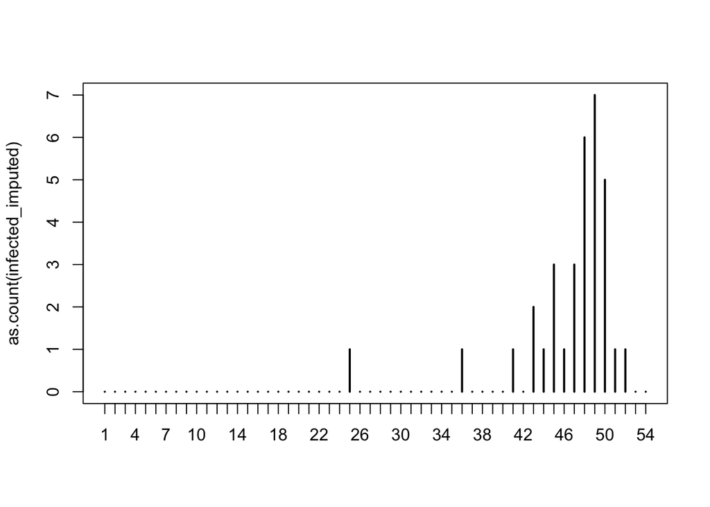

```r
as.count <- function(infected, last_date = 23+31) {
    table(factor(infected, levels = 1:last_date))
}
plot(as.count(infected_imputed))
```

# Distribution of the infection time

We can obtain a distribution of the infection time for these individuals by repeating the above procedure. To avoid just using one imputation of the sympton onset, we use the *mice* package to impute it using the arrival, initial medical visit, hospitalization, and confirmation dates (see [first preliminary analysis](https://htmlpreview.github.io/?https://github.com/qingyuanzhao/2019-nCov-Data/blob/master/Feb1.html)).

```r
set.seed(20200204)
m <- 100
symptom_imputed <- multiple.impute.onset(data, m = m)
```

We then impute the infection time using the same algorithm as above.

```r
OI_imputed_one <- matrix(0, N, m)
OI_imputed_mean <- matrix(0, N, m)
for (i in 1:m) {
  OI_tmp <- matrix(0, N, m)
  for (j in 1:m){
    infected_imputed <- impute.infected(symptom_imputed[, i], data$Infected_first, data$Infected_last,
                                        incubation_alpha = 1.92, incubation_beta = 0.37)
    OI_tmp[, j] <- as.count(infected_imputed)
  }
  OI_imputed_one[, i] <- OI_tmp[, 1]
  OI_imputed_mean[, i] <- apply(OI_tmp, 1, mean)
}
```

For each imputation of the symptom onset, we average over $100$ imputations to estimate the distribution of the infection time and compare them. In the figure below, each black point represents a realization of the infection count. Their means are represented by the red curve, and the one standard deviations of the means over different imputations of the symptom onset are shown by error bars.

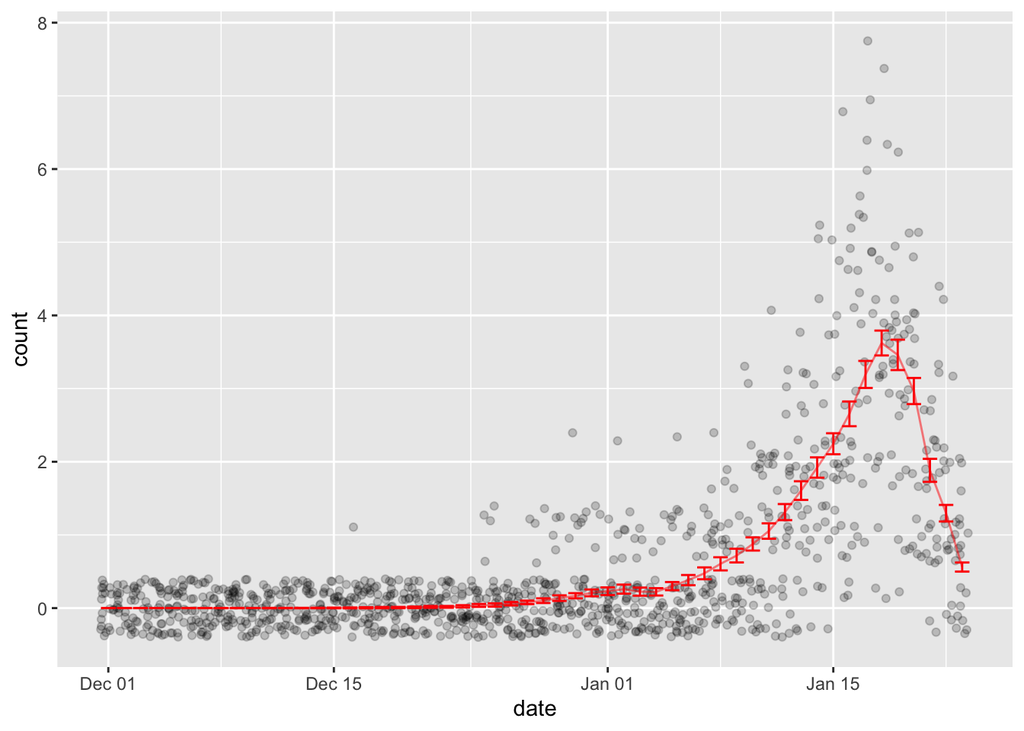

```r
library(reshape2)
library(ggplot2)
df <- melt(OI_imputed_one[, 1:20])
names(df) <- c("date", "impute", "count")
df$date <- df$date - 1 + as.Date("2019-12-01")
df_summary <- data.frame(date = 1:N - 1 + as.Date("2019-12-01"),
                         count_mean = apply(OI_imputed_mean, 1, mean),
                         count_sd = apply(OI_imputed_mean, 1, sd))
ggplot() + aes(x = date) +
  geom_point(data = df, aes(y = count), position = position_jitter(width = 0.5), alpha = 0.2) +
  geom_line(data = df_summary, aes(y = count_mean), alpha = 0.5, col = "red") +
  geom_errorbar(data = df_summary, aes(ymin = count_mean - count_sd, ymax = count_mean + count_sd), col = "red")
```

Not surprisingly, imputing the few missing symptom onset dates did not lead to dramatic change of the estimated distributions of infection counts.

We see that the infection counts were initially growing exponentially but dropped in the last few days. This phenomenon may look surprising in the beginning, but actually this is due to we are using a sample that left Wuhan before the lockdown. For people infected on January 22, there was not enough time for all of them to leave. Due to the nature of our sample, we posit the following model. Let $WI_t$ be the number of new infections in Wuhan on day $t$, among which $OI_t$ left Wuhan on or before January 23. We assume $WI_t$ was growing exponentially before January 23:
$$\begin{equation} \label{eq:wi}
WI_t = WI_0 \cdot e^{rt}
\end{equation}$$
and $OI_t$ follows a Poisson distribution:
$$\begin{equation} \label{eq:oi}
OI_t \sim \text{Poisson}(OP * (N - t + 1) * WI_t),
\end{equation}$$
where the $OP$ is a constant representing the proportion of people leaving Wuhan. An immediate consequence of this model is that the logarithm of the expectation of $OI_t$ is given by
$$\begin{equation} \label{eq:log-linear}
\log\big(\mathbb{E}[OI_t]\big) = rt + \log(N - t + 1) + \text{constant}.
\end{equation}$$

We can verify this model by estimating the left hand side using random samples of $(OI_t)_{t=1}^N$:

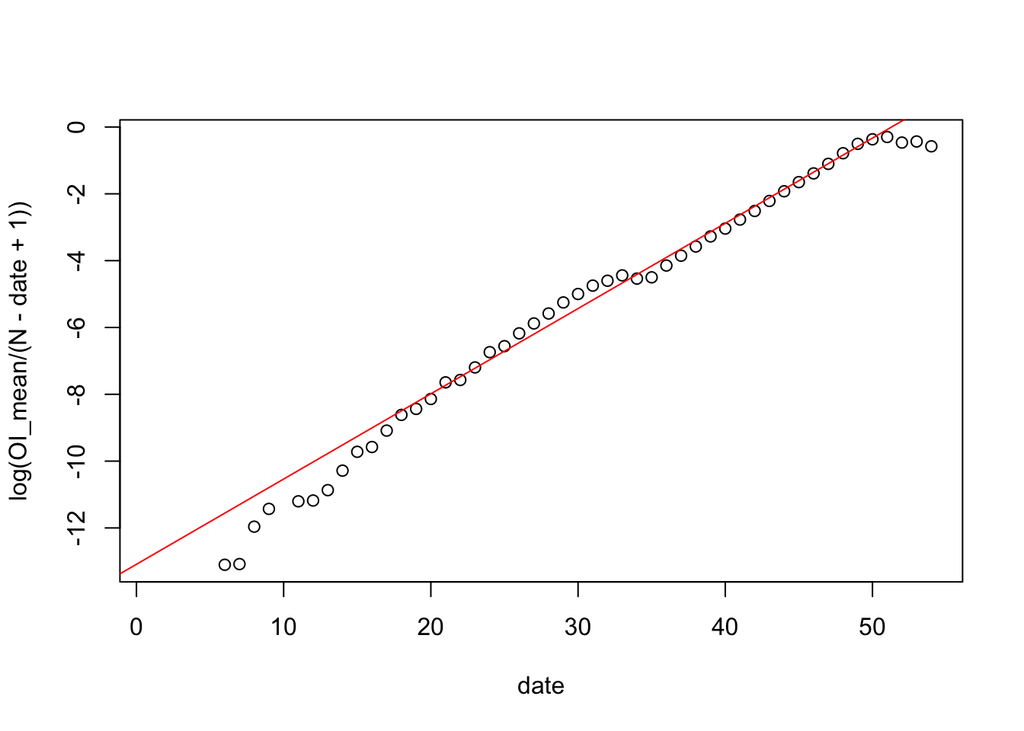

```r
df <- data.frame(date = 1:N, OI_mean = apply(OI_imputed_mean, 1, mean))
plot(log(OI_mean / (N - date + 1)) ~ date, df)
fit <- lm(log(OI_mean / (N - date + 1)) ~ date, subset(df, date > 15 & date < 50))
abline(fit$coefficients[1], fit$coefficients[2], col = "red")
```

The slope of this simple straight line fit, which estimates $r$ according to the last display, is given by

```r
(r <- fit$coef[2])
```

```
##    date
## 0.25518
```

This estimate means that the epidemic was doubling every

```r
log(2) / r
```

```
##     date
## 2.716307
```

days. We can use the equation (3.4) in [Wallinga and Lipsitch (2006)](https://royalsocietypublishing.org/doi/full/10.1098/rspb.2006.3754) to estimate the basic reproduction number from $r$. This formula assumes the serial interval is normally distributed, and we will use the mean 7.5 and standard deviation 3.4 reported by [Li et al. (2020)](https://www.nejm.org/doi/full/10.1056/NEJMoa2001316).

```r
r.to.R <- function(r, si_mean = 7.5, si_sd = 3.4) {
    exp(r * si_mean - r^2 * si_sd^2 / 2)
}
r.to.R(r)
```

```
##     date
## 4.652826
```

This is much higher than the $R_0$ estimated by [Li et al. (2020)](https://www.nejm.org/doi/full/10.1056/NEJMoa2001316).

# Uncertainty quantification

The above analysis does not recognize the fact that the distribution of $(OI_t)_{t=1}^N$ is drawn based on the observed cases, which is only a small (hopefully random) sample of the cases in Wuhan. We use Bayesian inference to quantify the sampling uncertainty. For each draw of $(OI_t)_{t=1}^n$, we fit the above model with the following prior:
$$\begin{align*}
r &\sim \text{Exponential}(\text{mean} = \log(2)/7.4),\\
WI_{32} &\sim \text{Gamma}(\text{mean} = 50, \text{sd} = 100), \\
OP &\sim \text{Exponential}(OP_\text{prior}).
\end{align*}$$

The prior mean of $r$ is chosen as the estimate from [Li et al. (2020)](https://www.nejm.org/doi/full/10.1056/NEJMoa2001316) who estimated the cases were doubly every $7.4$ days. We choose to put a diffuse Gamma prior on $WI_{32}$, the number of new infections on January 1st, which is more interpretable than $WI_1$.

```r
stan_data <- list(N = N,
                  r_prior_mean = log(2) / 7.4,
                  WI_Jan1_prior_mean = 50,
                  WI_Jan1_prior_sd = 100)
```

Finally we put an exponential prior on $OP$, the proportion of people leaving from Wuhan to the selected Asian countries/regions. We estimate the travel to the selected Asian countries/regions using air traffic planning data from December 30, 2019 to January 22, 2020, reported by this [web article](https://www.jiqizhixin.com/articles/2020-01-27-2). We assume twice as many people entered Hong Kong and Macau via train/car/ferry than air. We assume 80% of the planned aircraft seats were taken.

```r
daily_travel <- (7078 * 3 + # Hong Kong
                  6154 * 3 + # Macau
                  3696 + 2698 + 1121 + # Taiwan
                  10680 + # Singapore
                  9080 + 6272 + 2656 + # Japan
                  6430) / 24 * 0.8  # Korea
daily_travel
```

```
## [1] 2744.3
```

```r
stan_data$OP_prior_mean <- daily_travel / 11000000 ## divide by Wuhan's population
```

The next code chunk implements this Bayesian model in *stan*:

```r
stan_code <- "
data {
  int<lower=0> N;
  int<lower=0> OI[N];
  real<lower=0> WI_Jan1_prior_mean;
  real<lower=0> WI_Jan1_prior_sd;
  real<lower=0> OP_prior_mean;
  real<lower=0> r_prior_mean;
}
parameters {
  real<lower=0> r;
  real<lower=0> WI_Jan1;
  real<lower=0> OP;
}
transformed parameters {
  vector[N] WI;
  vector[N] OI_mean;
  for (t in 1:N) {
    WI[t] = WI_Jan1 * exp(r * (t - 32));
    OI_mean[t] = (N - t + 1) * OP * WI[t];
  }
}
model {
  r ~ exponential(1 / r_prior_mean);
  WI_Jan1 ~ gamma(WI_Jan1_prior_mean^2 / WI_Jan1_prior_sd^2,
                  WI_Jan1_prior_mean / WI_Jan1_prior_sd^2);
  OP ~ exponential(1 / OP_prior_mean);
  OI ~ poisson(OI_mean);
}
generated quantities {
  vector[N] WT;
  WT = cumulative_sum(WI);
}
"

library(rstan)
options(mc.cores = parallel::detectCores())
rstan_options(auto_write = TRUE)
sm <- stan_model(model_code = stan_code)
```

```r
obtain.posterior <- function(symptom_imputed, stan_data, incubation_alpha = 1.92, incubation_beta = 0.37) {

  posterior <- list()
  for (impute in 1:m) {
    infected_imputed <- impute.infected(symptom_imputed[, impute],
                                        data$Infected_first, data$Infected_last,
                                        incubation_alpha, incubation_beta)
    stan_data$OI <- as.count(infected_imputed, N)
    capture.output(fit <- sampling(sm, data  = stan_data, init = 3, iter = 20000, thin = 10),
                   file = "NUL") # supress the output of stan
    if (impute %% round(m/5) == 0)
      print(fit, pars = "r")
    posterior[[impute]] <- extract(fit)
  }
  posterior

}

m <- 20

set.seed(20200204)
symptom_imputed <- multiple.impute.onset(data, m = m)
posterior <- obtain.posterior(symptom_imputed, stan_data)
```

```
## Inference for Stan model: 1279568e49d6986bdd923c171bee1b91.
## 4 chains, each with iter=20000; warmup=10000; thin=10;
## post-warmup draws per chain=1000, total post-warmup draws=4000.
##
##   mean se_mean   sd 2.5%  25%  50%  75% 97.5% n_eff Rhat
## r 0.24       0 0.03 0.19 0.22 0.24 0.26   0.3  3882    1
##
## Samples were drawn using NUTS(diag_e) at Wed Feb  5 13:02:08 2020.
## For each parameter, n_eff is a crude measure of effective sample size,
## and Rhat is the potential scale reduction factor on split chains (at
## convergence, Rhat=1).
## Inference for Stan model: 1279568e49d6986bdd923c171bee1b91.
## 4 chains, each with iter=20000; warmup=10000; thin=10;
## post-warmup draws per chain=1000, total post-warmup draws=4000.
##
##   mean se_mean   sd 2.5%  25%  50%  75% 97.5% n_eff Rhat
## r 0.24       0 0.03 0.18 0.22 0.24 0.26   0.3  3996    1
##
## Samples were drawn using NUTS(diag_e) at Wed Feb  5 13:02:29 2020.
## For each parameter, n_eff is a crude measure of effective sample size,
## and Rhat is the potential scale reduction factor on split chains (at
## convergence, Rhat=1).
## Inference for Stan model: 1279568e49d6986bdd923c171bee1b91.
## 4 chains, each with iter=20000; warmup=10000; thin=10;
## post-warmup draws per chain=1000, total post-warmup draws=4000.
##
##   mean se_mean   sd 2.5% 25%  50%  75% 97.5% n_eff Rhat
## r 0.22       0 0.03 0.17 0.2 0.22 0.24  0.27  3808    1
##
## Samples were drawn using NUTS(diag_e) at Wed Feb  5 13:02:51 2020.
## For each parameter, n_eff is a crude measure of effective sample size,
## and Rhat is the potential scale reduction factor on split chains (at
## convergence, Rhat=1).
## Inference for Stan model: 1279568e49d6986bdd923c171bee1b91.
## 4 chains, each with iter=20000; warmup=10000; thin=10;
## post-warmup draws per chain=1000, total post-warmup draws=4000.
##
##   mean se_mean   sd 2.5%  25%  50%  75% 97.5% n_eff Rhat
## r 0.23       0 0.03 0.18 0.22 0.23 0.25  0.29  3780    1
##
## Samples were drawn using NUTS(diag_e) at Wed Feb  5 13:03:11 2020.
## For each parameter, n_eff is a crude measure of effective sample size,
## and Rhat is the potential scale reduction factor on split chains (at
## convergence, Rhat=1).
## Inference for Stan model: 1279568e49d6986bdd923c171bee1b91.
## 4 chains, each with iter=20000; warmup=10000; thin=10;
## post-warmup draws per chain=1000, total post-warmup draws=4000.
##
##   mean se_mean   sd 2.5% 25%  50%  75% 97.5% n_eff Rhat
## r 0.22       0 0.03 0.17 0.2 0.22 0.24  0.28  3909    1
##
## Samples were drawn using NUTS(diag_e) at Wed Feb  5 13:03:31 2020.
## For each parameter, n_eff is a crude measure of effective sample size,
## and Rhat is the potential scale reduction factor on split chains (at
## convergence, Rhat=1).
```

The posterior mean and 95% credible interval of $r$ is

```r
r_posterior <- unlist(lapply(posterior, function(posterior) posterior$r))
my.summary <- function(x) {c(mean = mean(x), CI.low = quantile(x, 0.025), CI.up = quantile(x, 0.975))}
my.summary(r_posterior)
```

```
##        mean CI.low.2.5% CI.up.97.5%
##   0.2277184   0.1712572   0.2940608
```

```r
my.summary(log(2) / r_posterior) ## doubling days
```

```
##        mean CI.low.2.5% CI.up.97.5%
##    3.102553    2.357156    4.047405
```

```r
my.summary(r.to.R(r_posterior)) ## R0
```

```
##        mean CI.low.2.5% CI.up.97.5%
##    4.112218    3.049285    5.504959
```

# Sensitivity analysis

## Sensitivity to $OP_{\text{prior}}$

In the *stan* code we have also generated the total number of infections in Wuhan by the end of January 23.

```r
WT_Jan23_posterior <-
  unlist(lapply(posterior, function(posterior) posterior$WT[, N]))
my.summary(WT_Jan23_posterior)
```

```
##        mean CI.low.2.5% CI.up.97.5%
##   53866.530    6614.954  238120.902
```

However, this is not very reliable because it is closely correlated with the assumed rate of international traveling. People who traveled internationally are also more likely to be living in the city center and might have higher chances of infection.

Nevertheless, the growth exponent $r$ should be relatively insensitive to the choice. This is illustrated below where we assume the the prior mean of $OP$ is five times as before.

```r
stan_data$OP_prior_mean <- stan_data$OP_prior_mean * 5

set.seed(20200204)
symptom_imputed <- multiple.impute.onset(data, m = m)
posterior2 <- obtain.posterior(symptom_imputed, stan_data)
```

```
## Inference for Stan model: 1279568e49d6986bdd923c171bee1b91.
## 4 chains, each with iter=20000; warmup=10000; thin=10;
## post-warmup draws per chain=1000, total post-warmup draws=4000.
##
##   mean se_mean   sd 2.5%  25%  50%  75% 97.5% n_eff Rhat
## r 0.24       0 0.03 0.19 0.22 0.24 0.26   0.3  4063    1
##
## Samples were drawn using NUTS(diag_e) at Wed Feb  5 13:04:02 2020.
## For each parameter, n_eff is a crude measure of effective sample size,
## and Rhat is the potential scale reduction factor on split chains (at
## convergence, Rhat=1).
## Inference for Stan model: 1279568e49d6986bdd923c171bee1b91.
## 4 chains, each with iter=20000; warmup=10000; thin=10;
## post-warmup draws per chain=1000, total post-warmup draws=4000.
##
##   mean se_mean   sd 2.5%  25%  50%  75% 97.5% n_eff Rhat
## r 0.24       0 0.03 0.19 0.22 0.24 0.26   0.3  4053    1
##
## Samples were drawn using NUTS(diag_e) at Wed Feb  5 13:04:25 2020.
## For each parameter, n_eff is a crude measure of effective sample size,
## and Rhat is the potential scale reduction factor on split chains (at
## convergence, Rhat=1).
## Inference for Stan model: 1279568e49d6986bdd923c171bee1b91.
## 4 chains, each with iter=20000; warmup=10000; thin=10;
## post-warmup draws per chain=1000, total post-warmup draws=4000.
##
##   mean se_mean   sd 2.5% 25%  50%  75% 97.5% n_eff Rhat
## r 0.22       0 0.03 0.17 0.2 0.21 0.23  0.27  4027    1
##
## Samples were drawn using NUTS(diag_e) at Wed Feb  5 13:04:49 2020.
## For each parameter, n_eff is a crude measure of effective sample size,
## and Rhat is the potential scale reduction factor on split chains (at
## convergence, Rhat=1).
## Inference for Stan model: 1279568e49d6986bdd923c171bee1b91.
## 4 chains, each with iter=20000; warmup=10000; thin=10;
## post-warmup draws per chain=1000, total post-warmup draws=4000.
##
##   mean se_mean   sd 2.5%  25%  50%  75% 97.5% n_eff Rhat
## r 0.23       0 0.03 0.18 0.21 0.23 0.25  0.29  3791    1
##
## Samples were drawn using NUTS(diag_e) at Wed Feb  5 13:05:13 2020.
## For each parameter, n_eff is a crude measure of effective sample size,
## and Rhat is the potential scale reduction factor on split chains (at
## convergence, Rhat=1).
## Inference for Stan model: 1279568e49d6986bdd923c171bee1b91.
## 4 chains, each with iter=20000; warmup=10000; thin=10;
## post-warmup draws per chain=1000, total post-warmup draws=4000.
##
##   mean se_mean   sd 2.5% 25%  50%  75% 97.5% n_eff Rhat
## r 0.22       0 0.03 0.17 0.2 0.22 0.24  0.27  3846    1
##
## Samples were drawn using NUTS(diag_e) at Wed Feb  5 13:05:36 2020.
## For each parameter, n_eff is a crude measure of effective sample size,
## and Rhat is the potential scale reduction factor on split chains (at
## convergence, Rhat=1).
```

```r
r_posterior2 <- unlist(lapply(posterior2, function(posterior) posterior$r))
my.summary(r_posterior2)
```

```
##        mean CI.low.2.5% CI.up.97.5%
##   0.2254909   0.1695835   0.2920037
```

```r
WT_Jan23_posterior2 <-
  unlist(lapply(posterior2, function(posterior) posterior$WT[, N]))
my.summary(WT_Jan23_posterior2)
```

```
##        mean CI.low.2.5% CI.up.97.5%
##   20157.969    1470.988  113170.723
```

## Sensitivity to the incubation interval

Finally we assess the sensitivity of our results to the distribution of the incubation interval, which is crucial in imputing the infection time. So far we have used a Gamma distribution with $\alpha = 1.92$ and $\beta = 0.37$, which has mean 5.19 days and standard deviation 3.74 days. Next we use the slightly longer mean and standard deviation of the incubation interval of SARS (6.37 days and 4.08 days) in this [WHO report](https://www.who.int/csr/sars/en/WHOconsensus.pdf). We also use the serial interval of SARS reported by [Lipsitch et al. (2003)](https://science.sciencemag.org/content/300/5627/1966).

```r
stan_data$OP_prior_mean <- stan_data$OP_prior_mean / 5 # change the prior for OP back
set.seed(20200204)
symptom_imputed <- multiple.impute.onset(data, m = m)
posterior3 <- obtain.posterior(symptom_imputed, stan_data, incubation_alpha = 6.37^2 / 4.08^2, incubation_beta = 6.37 / 4.08^2)
```

```
## Inference for Stan model: 1279568e49d6986bdd923c171bee1b91.
## 4 chains, each with iter=20000; warmup=10000; thin=10;
## post-warmup draws per chain=1000, total post-warmup draws=4000.
##
##   mean se_mean   sd 2.5% 25%  50%  75% 97.5% n_eff Rhat
## r 0.21       0 0.03 0.17 0.2 0.21 0.23  0.27  3847    1
##
## Samples were drawn using NUTS(diag_e) at Wed Feb  5 13:05:56 2020.
## For each parameter, n_eff is a crude measure of effective sample size,
## and Rhat is the potential scale reduction factor on split chains (at
## convergence, Rhat=1).
## Inference for Stan model: 1279568e49d6986bdd923c171bee1b91.
## 4 chains, each with iter=20000; warmup=10000; thin=10;
## post-warmup draws per chain=1000, total post-warmup draws=4000.
##
##   mean se_mean   sd 2.5%  25%  50%  75% 97.5% n_eff Rhat
## r 0.21       0 0.03 0.16 0.19 0.21 0.23  0.26  4281    1
##
## Samples were drawn using NUTS(diag_e) at Wed Feb  5 13:06:14 2020.
## For each parameter, n_eff is a crude measure of effective sample size,
## and Rhat is the potential scale reduction factor on split chains (at
## convergence, Rhat=1).
## Inference for Stan model: 1279568e49d6986bdd923c171bee1b91.
## 4 chains, each with iter=20000; warmup=10000; thin=10;
## post-warmup draws per chain=1000, total post-warmup draws=4000.
##
##   mean se_mean   sd 2.5%  25% 50%  75% 97.5% n_eff Rhat
## r  0.2       0 0.02 0.15 0.18 0.2 0.21  0.25  3863    1
##
## Samples were drawn using NUTS(diag_e) at Wed Feb  5 13:06:32 2020.
## For each parameter, n_eff is a crude measure of effective sample size,
## and Rhat is the potential scale reduction factor on split chains (at
## convergence, Rhat=1).
## Inference for Stan model: 1279568e49d6986bdd923c171bee1b91.
## 4 chains, each with iter=20000; warmup=10000; thin=10;
## post-warmup draws per chain=1000, total post-warmup draws=4000.
##
##   mean se_mean   sd 2.5%  25% 50%  75% 97.5% n_eff Rhat
## r  0.2       0 0.02 0.15 0.18 0.2 0.21  0.25  3848    1
##
## Samples were drawn using NUTS(diag_e) at Wed Feb  5 13:06:49 2020.
## For each parameter, n_eff is a crude measure of effective sample size,
## and Rhat is the potential scale reduction factor on split chains (at
## convergence, Rhat=1).
## Inference for Stan model: 1279568e49d6986bdd923c171bee1b91.
## 4 chains, each with iter=20000; warmup=10000; thin=10;
## post-warmup draws per chain=1000, total post-warmup draws=4000.
##
##   mean se_mean   sd 2.5%  25%  50%  75% 97.5% n_eff Rhat
## r 0.19       0 0.02 0.15 0.18 0.19 0.21  0.24  4059    1
##
## Samples were drawn using NUTS(diag_e) at Wed Feb  5 13:07:07 2020.
## For each parameter, n_eff is a crude measure of effective sample size,
## and Rhat is the potential scale reduction factor on split chains (at
## convergence, Rhat=1).
```

```r
r_posterior3 <- unlist(lapply(posterior3, function(posterior) posterior$r))
my.summary(r_posterior3)
```

```
##        mean CI.low.2.5% CI.up.97.5%
##   0.2025645   0.1497702   0.2662865
```

```r
my.summary(log(2) / r_posterior3) ## doubling days
```

```
##        mean CI.low.2.5% CI.up.97.5%
##    3.496623    2.603013    4.628071
```

```r
my.summary(r.to.R(r_posterior, si_mean = 7.5, si_sd = 3.4)) ## incubation: 2019-nCoV, serial: 2019-nCoV
```

```
##        mean CI.low.2.5% CI.up.97.5%
##    4.112218    3.049285    5.504959
```

```r
my.summary(r.to.R(r_posterior, si_mean = 8.4, si_sd = 3.8)) ## incubation: 2019-nCoV, serial: SARS
```

```
##        mean CI.low.2.5% CI.up.97.5%
##    4.682951    3.410316    6.333068
```

```r
my.summary(r.to.R(r_posterior3, si_mean = 7.5, si_sd = 3.4)) ## incabation: SARS, serial: 2019-nCoV
```

```
##        mean CI.low.2.5% CI.up.97.5%
##    3.627651    2.701007    4.890515
```

```r
my.summary(r.to.R(r_posterior3, si_mean = 8.4, si_sd = 3.8)) ## incubation: SARS, serial: SARS
```

```
##        mean CI.low.2.5% CI.up.97.5%
##    4.103894    2.992524    5.611664
```